# Compare Transcript TPMs - Experiments

Mervin Fansler

26 May 2023

# Overview

Here we compare mESCs from four datasets:

- Lackford et al., 2014 ([article](https://doi.org/10.1002/embj.201386537) | [data](https://www.ncbi.nlm.nih.gov/sra/SRX304982))
- Nam et al., 2014 ([article](https://doi.org/10.1016/j.molcel.2014.02.013) | [data](https://www.ncbi.nlm.nih.gov/geo/query/acc.cgi?acc=GSM1268958))
- Guo et al., 2019 ([article](https://doi.org/10.1016/j.molcel.2019.01.042) | [data](https://www.ncbi.nlm.nih.gov/sra/SRX5437425))
- Bleckwehl et al., 2021 ([preprint](https://www.biorxiv.org/content/10.1101/2020.07.07.192427v2) | [data](https://www.ncbi.nlm.nih.gov/geo/query/acc.cgi?acc=GSM4694997))

## Data Description

### Cell Cultures

The Lackford data is based on **E14Tg2a** cells ([129/Ola strain](http://www.informatics.jax.org/strain/MGI:2160930)) cultured in [ESGRO Complete PLUS Clonal Grade Medium (Millipore)](https://www.emdmillipore.com/US/en/product/ESGRO-Complete-PLUS-Clonal-Grade-Medium-500ml,MM_NF-SF001-500P), which uses a specific (but proprietary) GSK3β inhibitor and a serum-free condition that does not require LIF.

The Nam data lists [**129S5/SvEvBrd**](http://www.informatics.jax.org/strain/MGI:3487126) as the strain. Culture conditions are not specified in article, supplement, GEO, or SRA.

The Guo data is based on OG2 transgenic mouse embryonic stem cells, with a strain background of 1/2 129SVJ+3/8 C57B6+1/8 CBA. Cells were cultured on feeder layers with 2iL medium (high glucose DMEM, 15%FBS, NEAA, GlutaMAX, LIF) plus 2i (1 mm PD0325901, 3 mm CHIR99021) and LIF.

The Bleckwehl data is based on **E14Tg2a** cells ([129/Ola strain](http://www.informatics.jax.org/strain/MGI:2160930)) cultured in 2i+LIF conditions (serum-free N2B27 medium supplemented with MEK inhibitor PD0325901 [0.4 μM, Miltenyi Biotec], GSK3β inhibitor CHIR99021 [3 μM, Amsbio], and LIF).

### Library Preparation and Sequencing

Lackford used [a direct RNA sequencing protocol](https://dx.doi.org/10.1007%2F978-1-61779-089-8_4) performed by Helicos BioSciences.

Nam used [a 3P-Seq protocol](http://bartellab.wi.mit.edu/protocols/3PSeqV2.pdf) based on [Jan et al., 2011](https://doi.org/10.1038/nature09616), that uses 16-20 amplification cycles.

Bleckwehl and Guo used a 10X Chromium 3’ sequencing kit (v2 chemistry).

### Quantification

Lackford and Nam quantifications come from [PolyASite v2](https://polyasite.unibas.ch/samples) ([pipeline](https://github.com/zavolanlab/polyAsite_workflow)).

Bleckwehl and Guo are quantified through the `scutr-quant` pipeline.

# Methods

```r
## Loading PolyASite BED files
mm10_seqinfo <- seqinfo(getBSgenome("mm10")) %>% keepStandardChromosomes

extra_cols_polyasite <- c(pct_samples="numeric", n_protocols="integer",
                          mean_tpm="numeric", region="factor", pas="character")

import_polyasite <- function(...) {
  import(..., format="BED", extraCols=extra_cols_polyasite) %>%
    mutate(tpm=score) %>%
    select(name, tpm, 3:7) %>%
    `seqlevelsStyle<-`("UCSC") %>%
    `seqlevels<-`(value=seqlevels(mm10_seqinfo), pruning.mode='coarse') %>%
    `seqinfo<-`(value=mm10_seqinfo)
}

lower_geom_point_pct <- function (data, mapping, ...) {
  ggplot(data=data, mapping=mapping, ...) +
    geom_point_rast(size=0.5, alpha=0.5, pch=16, ...) +
    geom_abline(linetype='dashed', color='red') +
    lims(x=c(0,1), y=c(0,1))
}

lower_geom_point <- function (data, mapping, ...) {
  ggplot(data=data, mapping=mapping, ...) +
    geom_point_rast(size=0.5, alpha=0.5, pch=16, ...) +
    geom_abline(linetype='dashed', color='red')
}
```

# Load Data

```r
bleckwehl_samples=c("2i_ESC"="Bleckwehl21", "d2_EB"="Bleckwehl21_EB2", "d4_EB"="Bleckwehl21_EB4")
guo_samples=c("mESC"="Guo19")

gr_nam <- import_polyasite("data/bed/polyasite/nam14/mESC_WT.bed.gz")
gr_lackford <- import_polyasite("data/bed/polyasite/lackford14/mESC_WT.bed.gz")

sce_bleckwehl <- readRDS("data/sce/utrome_mm10_v2/bleckwehl21.txs.Rds") %>%
  `[`(, .$sample_id %in% names(bleckwehl_samples))

sce_guo <- readRDS("data/sce/utrome_mm10_v2/guo19.txs.Rds") %>%
  `[`(, .$sample_id %in% names(guo_samples))
```

## Merge Single Cell

```r
colData(sce_bleckwehl) %<>%
  as_tibble %>%
  mutate(sample_id=bleckwehl_samples[sample_id]) %>%
  dplyr::select(cell_id, sample_id) %>%
  column_to_rownames("cell_id") %>%
  DataFrame()

colData(sce_guo) %<>%
  as_tibble %>%
  mutate(sample_id=guo_samples[sample_id]) %>%
  dplyr::select(cell_id, sample_id) %>%
  column_to_rownames("cell_id") %>%
  DataFrame()

sce <- cbind(sce_guo, sce_bleckwehl)
```

## Filter Data

```r
# Filter to top two non-overlapping UTRs
df_utr2 <- rowData(sce) %>%
  as_tibble %>%
  dplyr::select(transcript_id, gene_id, gene_name, is_ipa, utr_type_no_ipa) %>%
  mutate(total_umis=rowSums(counts(sce)),
         tpm=total_umis*1e6/sum(total_umis, na.rm=TRUE)) %>%
  filter(!is_ipa, utr_type_no_ipa == 'multi') %>%
  group_by(gene_id) %>%
  filter(dplyr::n() > 1) %>%
  mutate(utr_rank=row_number(-total_umis)) %>%
  ungroup() %>%
  filter(utr_rank %in% 1:2)

idx_utr2 <- rowRanges(sce)[df_utr2$transcript_id,] %>%
  unlist() %>%
  join_overlap_self_directed() %>%
  filter(transcript_id != transcript_id.overlap) %>%
  { filter(df_utr2, !(transcript_id %in% .$transcript_id)) } %>%
  group_by(gene_id) %>%
  filter(dplyr::n() == 2) %>%
  ungroup() %$%
  transcript_id
```

# TPM

## Compute Bulk

```r
df_nam <- gr_nam %>%
  anchor_center() %>%
  mutate(width=50) %>%
  join_overlap_intersect_directed(x=unlist(rowRanges(sce)[idx_utr2,])) %>%
  group_by(transcript_id) %>%
  summarise(tpm=sum(tpm, na.rm=TRUE)) %>%
  as_tibble() %>%
  dplyr::rename(Nam14=tpm)

df_lackford <- gr_lackford %>%
  anchor_center() %>%
  mutate(width=50) %>%
  join_overlap_intersect_directed(x=unlist(rowRanges(sce)[idx_utr2,])) %>%
  group_by(transcript_id) %>%
  summarise(tpm=sum(tpm, na.rm=TRUE)) %>%
  as_tibble() %>%
  dplyr::rename(Lackford14=tpm)
```

## Compute Single-Cell

```r
M_samples <- fac2sparse(sce$sample_id) %>% t

cts <- assay(sce, 'counts') %*% M_samples

df_sc <- (cts %*% Diagonal(ncol(cts), 1e6/colSums(cts), names=TRUE)) %>%
  `[`(idx_utr2, , drop=FALSE) %>%
  as.matrix %>%
  as_tibble(rownames='transcript_id')
```

## Merge Data

```r
df_tpm <- df_sc %>%
  left_join(df_nam, by='transcript_id') %>%
  left_join(df_lackford, by='transcript_id') %>%
  mutate(across(where(is.numeric), coalesce, 0)) %>%
  left_join(select(df_utr2, transcript_id, gene_id, total_umis, utr_rank),
            by='transcript_id') %>%
  select(transcript_id, gene_id, utr_rank, total_umis, everything())
SAMPLE_COLS=c("Nam14", "Lackford14", "Guo19", "Bleckwehl21")
#SAMPLE_COLS=c("Nam14", "Lackford14", "Guo19", "Bleckwehl21", "Bleckwehl21_EB2", "Bleckwehl21_EB4")
MIN_TPM=0

df_tpm_min <- df_tpm %>%
  pivot_longer(all_of(SAMPLE_COLS), names_to="sample", values_to="tpm") %>%
  group_by(transcript_id) %>%
  filter(all(tpm > MIN_TPM)) %>%
  ungroup() %>%
  pivot_wider(names_from='sample', values_from='tpm') %>%
  group_by(gene_id) %>%
  filter(dplyr::n() == 2) %>%
  ungroup()
```

# Combined Figures

## TPM

### All genes

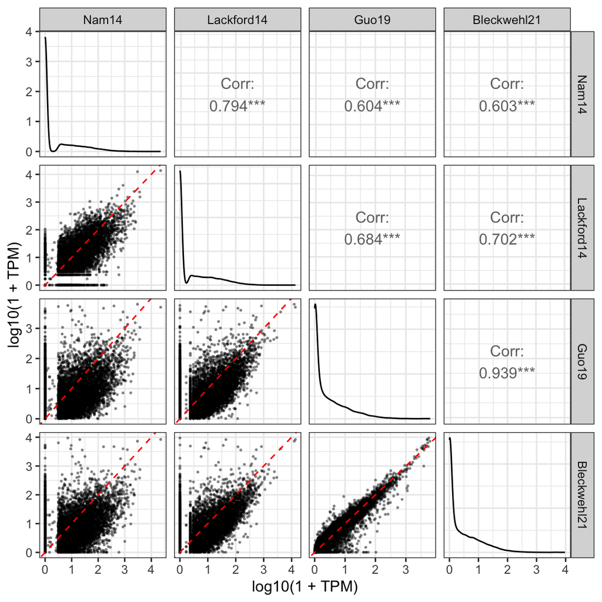

```r
df_tpm %>%
  mutate(across(all_of(SAMPLE_COLS), . %>% { log10(1+.) })) %>%
  ggpairs(columns=SAMPLE_COLS, progress=FALSE,
          lower=list(continuous=wrap(lower_geom_point, alpha=0.2)),
          upper=list(continuous=wrap('cor', method="spearman"))) +
  ##        lower=list(continuous=wrap("points", alpha=0.2, size=0.2, pch=16))) +

  labs(x="log10(1 + TPM)", y="log10(1 + TPM)") +
  theme_bw()
```

```r
ggsave("output/figure2/ed2f-mescs-all-tpm.pdf", width=6, height=6, dpi=300)
```

### Two-UTR Genes

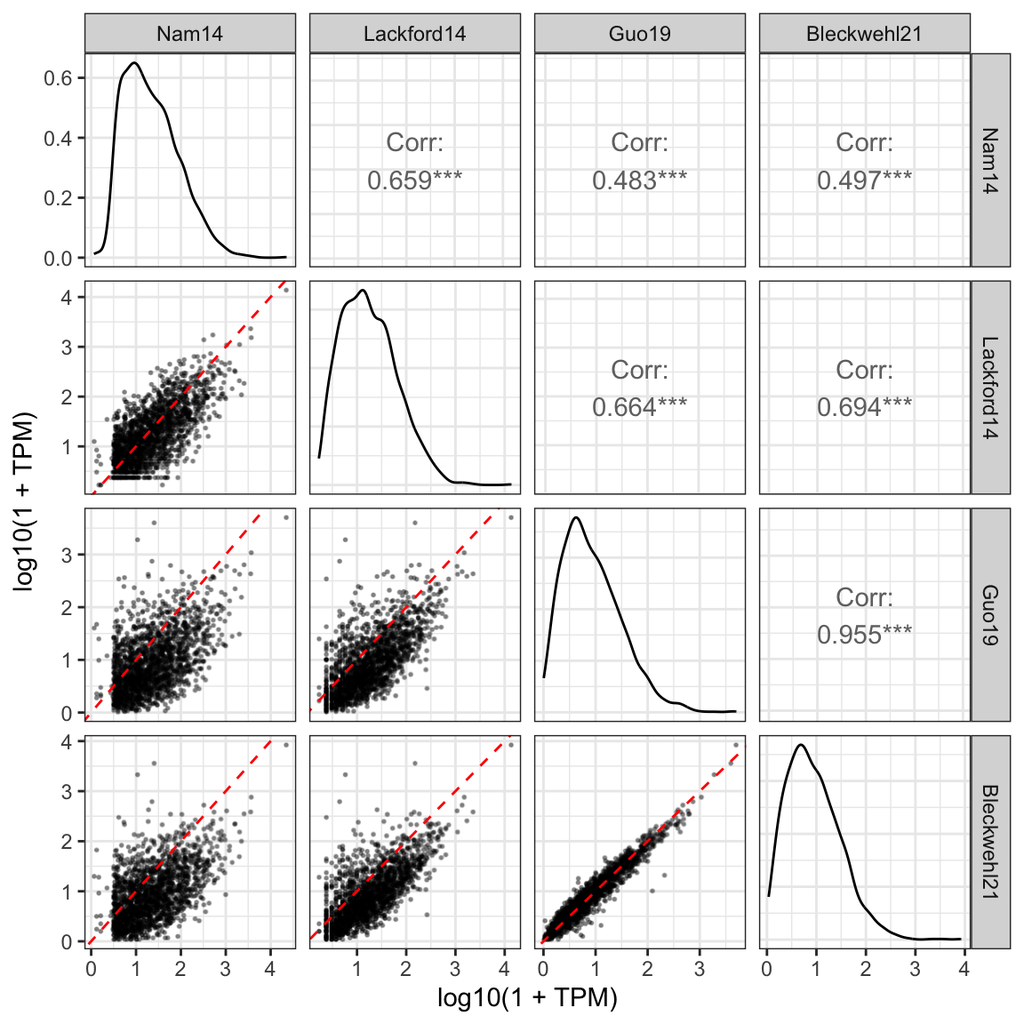

```r
df_tpm_min %>%
  mutate(across(all_of(SAMPLE_COLS), . %>% { log10(1+.) })) %>%
  ggpairs(columns=SAMPLE_COLS, progress=FALSE,
          lower=list(continuous=wrap(lower_geom_point, alpha=0.2)),
          upper=list(continuous=wrap('cor', method="spearman"))) +
          ##lower=list(continuous=wrap("points", alpha=0.2, size=0.2, pch=16))) +
  labs(x="log10(1 + TPM)", y="log10(1 + TPM)") +
  theme_bw()
```

# Exported Figures

## Bulk Compare

### TPM

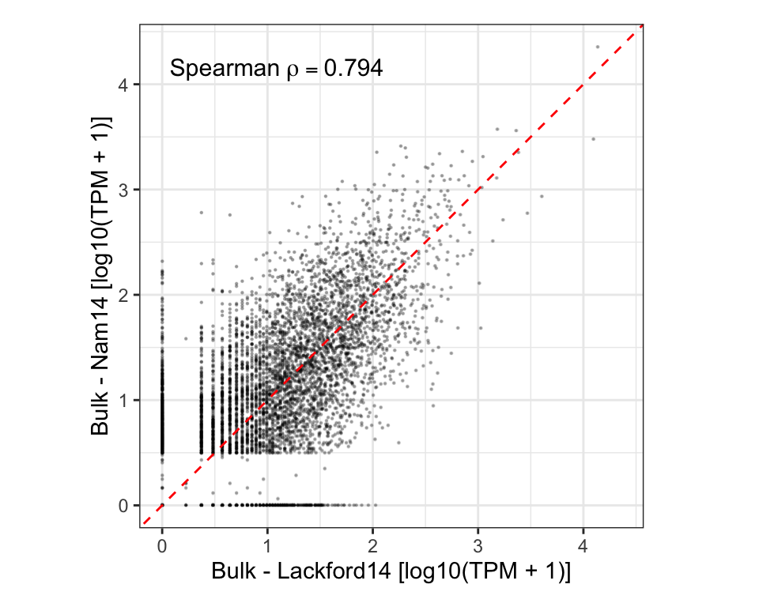

```r
axis_lims <- c(df_tpm$Lackford14, df_tpm$Nam14) %>%
  { log10(1 + .) } %>% { c(min(.), max(.)) }
label_rho_s <- sprintf("\"Spearman\" ~ rho == \"%0.3f\"",
                       cor(df_tpm$Nam14, df_tpm$Lackford14, method='spearman'))
label_lims <- axis_lims %>% { . + c(0.25*(.[2]-.[1]), 0.05*(.[1]-.[2])) }

df_tpm %>%
  ggplot(aes(x=log10(Lackford14+1), y=log10(Nam14+1))) +
  geom_point_rast(size=0.3, alpha=0.4, pch=16) +
  geom_abline(linetype='dashed', color='red') +
  annotate("text", x=label_lims[1], y=label_lims[2], label=label_rho_s,
           size=4, parse=TRUE) +
  scale_x_continuous(limits=axis_lims) + scale_y_continuous(limits=axis_lims) +
  labs(x="Bulk - Lackford14 [log10(TPM + 1)]", y="Bulk - Nam14 [log10(TPM + 1)]") +
  theme_bw() +
  theme(plot.margin=grid::unit(c(4,8,4,4), "mm"), aspect.ratio=1)
```

```r
ggsave("output/figure2/fig2g-mescs-bulk-bulk-tpm.pdf", width=5, height=4)
```

## Bulk vs scRNA-seq

### TPM

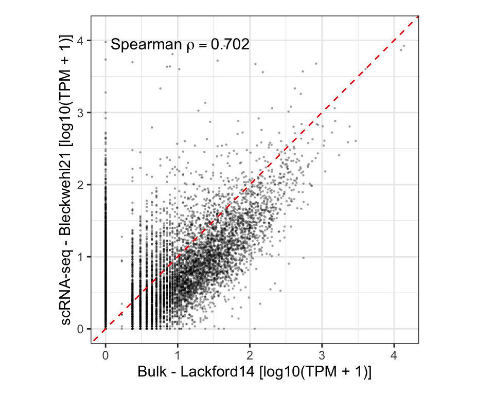

```r
axis_lims <- c(df_tpm$Lackford14, df_tpm$Bleckwehl21) %>%
  { log10(1 + .) } %>% { c(min(.), max(.)) }
label_lims <- axis_lims %>% { . + c(0.25*(.[2]-.[1]), 0.05*(.[1]-.[2])) }
label_rho_s <- sprintf("\"Spearman\" ~ rho == \"%0.3f\"",
                       cor(df_tpm$Lackford14, df_tpm$Bleckwehl21, method='spearman'))

df_tpm %>%
  ggplot(aes(x=log10(Lackford14+1), y=log10(Bleckwehl21+1))) +
  geom_point_rast(size=0.3, alpha=0.4, pch=16) +
  geom_abline(linetype='dashed', color='red') +
  annotate("text", x=label_lims[1], y=label_lims[2], label=label_rho_s,
           size=4, parse=TRUE) +
  scale_x_continuous(limits=axis_lims) + scale_y_continuous(limits=axis_lims) +
  labs(x="Bulk - Lackford14 [log10(TPM + 1)]", y="scRNA-seq - Bleckwehl21 [log10(TPM + 1)]") +
  theme_bw() +
  theme(plot.margin=grid::unit(c(4,8,4,4), "mm"), aspect.ratio=1)
```

```r
ggsave("output/figure2/fig2h-mescs-bulk-sc-tpm.pdf", width=5, height=4)
```

## scRNA-seq Compare

### TPM

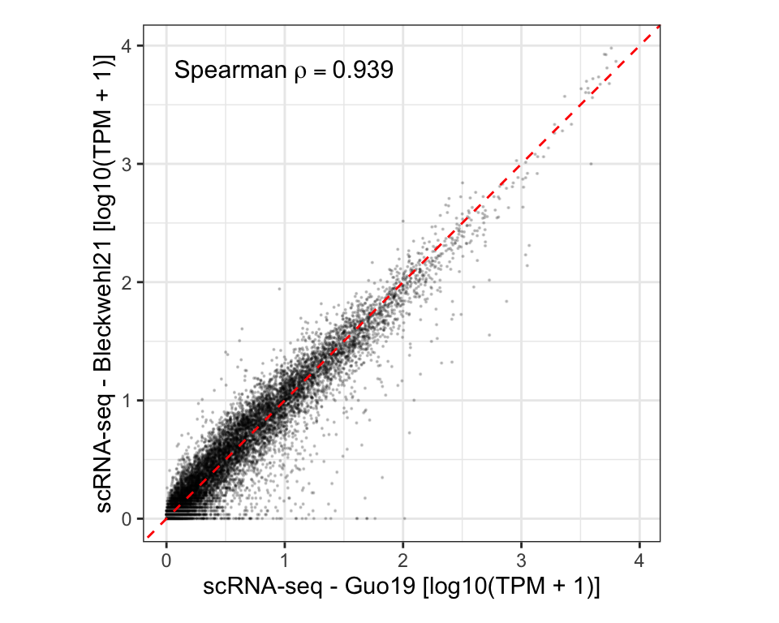

```r
axis_lims <- c(df_tpm$Guo19, df_tpm$Bleckwehl21) %>%
  { log10(1 + .) } %>% { c(min(.), max(.)) }
label_rho_s <- sprintf("\"Spearman\" ~ rho == \"%0.3f\"",
                       cor(df_tpm$Guo19, df_tpm$Bleckwehl21, method='spearman'))
label_lims <- axis_lims %>% { . + c(0.25*(.[2]-.[1]), 0.05*(.[1]-.[2])) }

df_tpm %>%
  ggplot(aes(x=log10(Guo19+1), y=log10(Bleckwehl21+1))) +
  geom_point_rast(size=0.2, alpha=0.3, pch=16) +
  geom_abline(linetype='dashed', color='red') +
  annotate("text", x=label_lims[1], y=label_lims[2], label=label_rho_s, size=4, parse=TRUE) +
  scale_x_continuous(limits=axis_lims) + scale_y_continuous(limits=axis_lims) +
  labs(x="scRNA-seq - Guo19 [log10(TPM + 1)]", y="scRNA-seq - Bleckwehl21 [log10(TPM + 1)]") +
  theme_bw() +
  theme(plot.margin=grid::unit(c(4,8,4,4), "mm"), aspect.ratio=1)
```

```r
ggsave("output/figure2/fig2i-mescs-sc-sc-tpm.pdf", width=5, height=4)
```

# Runtime Details

## Conda Environment

```
## Conda Environment YAML
name: bioc_3_16
channels:
  - merv
  - conda-forge
  - bioconda
  - defaults
dependencies:
  - _r-mutex=1.0.1=anacondar_1
  - argcomplete=2.0.0=pyhd8ed1ab_0
  - bioconductor-annotate=1.76.0=r42hdfd78af_0
  - bioconductor-annotationdbi=1.60.0=r42hdfd78af_0
  - bioconductor-annotationfilter=1.22.0=r42hdfd78af_0
  - bioconductor-annotationhub=3.6.0=r42hdfd78af_0
  - bioconductor-apeglm=1.20.0=r42hb890f52_0
  - bioconductor-batchelor=1.14.0=r42hb890f52_0
  - bioconductor-beachmat=2.14.0=r42hb890f52_0
  - bioconductor-biobase=2.58.0=r42h3be46a4_0
  - bioconductor-biocfilecache=2.6.0=r42hdfd78af_0
  - bioconductor-biocgenerics=0.44.0=r42hdfd78af_0
  - bioconductor-biocio=1.8.0=r42hdfd78af_0
  - bioconductor-biocneighbors=1.16.0=r42hb890f52_0
  - bioconductor-biocparallel=1.32.0=r42hb890f52_0
  - bioconductor-biocsingular=1.14.0=r42hb890f52_0
  - bioconductor-biocversion=3.16.0=r42hdfd78af_0
  - bioconductor-biomart=2.54.0=r42hdfd78af_0
  - bioconductor-biostrings=2.66.0=r42h3be46a4_0
  - bioconductor-biovizbase=1.46.0=r42h3be46a4_0
  - bioconductor-bluster=1.8.0=r42hb890f52_0
  - bioconductor-bsgenome=1.66.3=r42hdfd78af_0
  - bioconductor-bsgenome.hsapiens.ucsc.hg38=1.4.5=r42hdfd78af_0
  - bioconductor-bsgenome.mmusculus.ucsc.mm10=1.4.3=r42hdfd78af_2
  - bioconductor-celldex=1.8.0=r42hdfd78af_0
  - bioconductor-cellxgenedp=1.2.0=r42hdfd78af_0
  - bioconductor-clusterprofiler=4.6.0=r42hdfd78af_0
  - bioconductor-cner=1.34.0=r42h3be46a4_0
  - bioconductor-data-packages=20230420=hdfd78af_0
  - bioconductor-delayedarray=0.24.0=r42h3be46a4_0
  - bioconductor-delayedmatrixstats=1.20.0=r42hdfd78af_0
  - bioconductor-deseq2=1.38.0=r42hb890f52_0
```

[output cut: 539 more lines]

```
  - xorg-kbproto=1.0.7=h35c211d_1002
  - xorg-libice=1.0.10=h0d85af4_0
  - xorg-libsm=1.2.3=h0d85af4_1000
  - xorg-libx11=1.7.2=h0d85af4_0
  - xorg-libxau=1.0.9=h35c211d_0
  - xorg-libxdmcp=1.1.3=h35c211d_0
  - xorg-libxt=1.2.1=h0d85af4_2
  - xorg-xproto=7.0.31=h35c211d_1007
  - xz=5.2.6=h775f41a_0
  - yaml=0.2.5=h0d85af4_2
  - yq=2.13.0=pyhd8ed1ab_0
  - zipp=3.10.0=pyhd8ed1ab_0
  - zlib=1.2.13=hfd90126_4
  - zstd=1.5.2=hfa58983_4
prefix: /Users/mfansler/miniconda3/envs/bioc_3_16
```